# Describe Data

Dataset represents thousands of loans made through the Lending Club platform, which is a platform that allows individuals to lend to other individuals.

**Variable Description**

emp_title: Job title. \ emp_length: Number of years in the job, rounded down. \ If longer than 10 years, then this is represented by the value 10. \ state: Two-letter state code. \ home_ownership: The ownership status of the applicant's residence. \ annual_income: Annual income. \ verified_income: Type of verification of the applicant's income. \ debt_to_income: Debt-to-income ratio. \ annual_income_joint: If this is a joint application, then the annual income of the two parties applying. \ verification_income_joint: Type of verification of the joint income. \ debt_to_income_joint: Debt-to-income ratio for the two parties. \ delinq_2y: Delinquencies on lines of credit in the last 2 years. \ months_since_last_delinq: Months since the last delinquency. \ earliest_credit_line: Year of the applicant's earliest line of credit. \ inquiries_last_12m: Inquiries into the applicant's credit during the last 12 months. \ total_credit_lines: Total number of credit lines in this applicant's credit history. \ open_credit_lines: Number of currently open lines of credit. \ total_credit_limit: Total available credit, e. \g. \ if only credit cards, then the total of all the credit limits. \ This excludes a mortgage. \ total_credit_utilized: Total credit balance, excluding a mortgage. \ num_collections_last_12m: Number of collections in the last 12 months. \ This excludes medical collections. \ num_historical_failed_to_pay: The number of derogatory public records, which roughly means the number of times the applicant failed to pay. \ months_since_90d_late: Months since the last time the applicant was 90 days late on a payment. \ current_accounts_delinq: Number of accounts where the applicant is currently delinquent. \ total_collection_amount_ever: The total amount that the applicant has had against them in collections. \ current_installment_accounts: Number of installment accounts, which are (roughly) accounts with a fixed payment amount and period. \ A typical example might be a 36-month car loan. \ accounts_opened_24m: Number of new lines of credit opened in the last 24 months. \ months_since_last_credit_inquiry: Number of months since the last credit inquiry on this applicant. \ num_satisfactory_accounts: Number of satisfactory accounts. \ num_accounts_120d_past_due: Number of current accounts that are 120 days past due. \ num_accounts_30d_past_due: Number of current accounts that are 30 days past due. \ num_active_debit_accounts: Number of currently active bank cards. \ total_debit_limit: Total of all bank card limits. \ num_total_cc_accounts: Total number of credit card accounts in the applicant's history. \ num_open_cc_accounts: Total number of currently open credit card accounts. \ num_cc_carrying_balance: Number of credit cards that are carrying a balance. \ num_mort_accounts: Number of mortgage accounts. \ account_never_delinq_percent: Percent of all lines of credit where the applicant was never delinquent. \ tax_liens: a numeric vector. \ public_record_bankrupt: Number of bankruptcies listed in the public record for this applicant. \ loan_purpose: The category for the purpose of the loan. \ application_type: The type of application: either individual or joint. \ loan_amount: The amount of the loan the applicant received. \ term: The number of months of the loan the applicant received. \ interest_rate: Interest rate of the loan the applicant received. \ installment: Monthly payment for the loan the applicant received. \ grade: Grade associated with the loan. \ sub_grade: Detailed grade associated with the loan. \ issue_month: Month the loan was issued. \ loan_status: Status of the loan. \ initial_listing_status: Initial listing status of the loan. \ (I think this has to do with whether the lender provided the entire loan or if the loan is across multiple lenders). \ disbursement_method: Dispersement method of the loan. \ balance: Current balance on the loan. \ paid_total: Total that has been paid on the loan by the applicant. \ paid_principal: The difference between the original loan amount and the current balance on the loan. \ paid_interest: The amount of interest paid so far by the applicant. \ paid_late_fees: Late fees paid by the applicant. \

# Project Setup

```python
import pandas as pd
import numpy as np
pd.options.mode.chained_assignment = None

data = pd.read_csv('loans_full_schema.csv')
data.head()
```

|  | emp_title | emp_length | state | homeownership | annual_income | verified_income | debt_to_income | annual_income_joint | verification_income_joint | debt_to_income_joint | ... | sub_grade | issue_month | loan_status | initial_listing_status | disbursement_method | balance | paid_total | paid_principal | paid_interest | paid_late_fees |
| --- | --- | --- | --- | --- | --- | --- | --- | --- | --- | --- | --- | --- | --- | --- | --- | --- | --- | --- | --- | --- | --- |
| 0 | global config engineer | 3.0 | NJ | MORTGAGE | 90000.0 | Verified | 18.01 | NaN | NaN | NaN | ... | C3 | Mar-2018 | Current | whole | Cash | 27015.86 | 1999.33 | 984.14 | 1015.19 | 0.0 |
| 1 | warehouse office clerk | 10.0 | HI | RENT | 40000.0 | Not Verified | 5.04 | NaN | NaN | NaN | ... | C1 | Feb-2018 | Current | whole | Cash | 4651.37 | 499.12 | 348.63 | 150.49 | 0.0 |
| 2 | assembly | 3.0 | WI | RENT | 40000.0 | Source Verified | 21.15 | NaN | NaN | NaN | ... | D1 | Feb-2018 | Current | fractional | Cash | 1824.63 | 281.80 | 175.37 | 106.43 | 0.0 |
| 3 | customer service | 1.0 | PA | RENT | 30000.0 | Not Verified | 10.16 | NaN | NaN | NaN | ... | A3 | Jan-2018 | Current | whole | Cash | 18853.26 | 3312.89 | 2746.74 | 566.15 | 0.0 |
| 4 | security supervisor | 10.0 | CA | RENT | 35000.0 | Verified | 57.96 | 57000.0 | Verified | 37.66 | ... | C3 | Mar-2018 | Current | whole | Cash | 21430.15 | 2324.65 | 1569.85 | 754.80 | 0.0 |

5 rows × 55 columns

# Exploratory Analysis

Exploring features and its data types.

```python
data.info()
```

```
<class 'pandas.core.frame.DataFrame'>
RangeIndex: 10000 entries, 0 to 9999
Data columns (total 55 columns):
 #   Column                            Non-Null Count  Dtype
---  ------                            --------------  -----
 0   emp_title                         9167 non-null   object
 1   emp_length                        9183 non-null   float64
 2   state                             10000 non-null  object
 3   homeownership                     10000 non-null  object
 4   annual_income                     10000 non-null  float64
 5   verified_income                   10000 non-null  object
 6   debt_to_income                    9976 non-null   float64
 7   annual_income_joint               1495 non-null   float64
 8   verification_income_joint         1455 non-null   object
 9   debt_to_income_joint              1495 non-null   float64
```

[output cut: 47 more lines]

Finding Null counts of each features in the dataset.

```python
data.isnull().sum()
```

```
emp_title                            833
emp_length                           817
state                                  0
homeownership                          0
annual_income                          0
verified_income                        0
debt_to_income                        24
annual_income_joint                 8505
verification_income_joint           8545
debt_to_income_joint                8505
delinq_2y                              0
months_since_last_delinq            5658
earliest_credit_line                   0
inquiries_last_12m                     0
total_credit_lines                     0
open_credit_lines                      0
total_credit_limit                     0
total_credit_utilized                  0
num_collections_last_12m               0
num_historical_failed_to_pay           0
months_since_90d_late               7715
current_accounts_delinq                0
total_collection_amount_ever           0
current_installment_accounts           0
accounts_opened_24m                    0
months_since_last_credit_inquiry    1271
num_satisfactory_accounts              0
num_accounts_120d_past_due           318
num_accounts_30d_past_due              0
num_active_debit_accounts              0
total_debit_limit                      0
num_total_cc_accounts                  0
num_open_cc_accounts                   0
num_cc_carrying_balance                0
num_mort_accounts                      0
account_never_delinq_percent           0
tax_liens                              0
public_record_bankrupt                 0
loan_purpose                           0
application_type                       0
loan_amount                            0
term                                   0
interest_rate                          0
installment                            0
grade                                  0
sub_grade                              0
issue_month                            0
loan_status                            0
initial_listing_status                 0
disbursement_method                    0
balance                                0
paid_total                             0
paid_principal                         0
paid_interest                          0
paid_late_fees                         0
dtype: int64
```

Finding Categorical Values among the features with non-numerical data type explored previously.

```python
# Considering only non-numeric features.
data[
    [
        "emp_title",
        "state",
        "homeownership",
        "verified_income",
        "verification_income_joint",
        "loan_purpose",
        "application_type",
        "grade",
        "sub_grade",
        "issue_month",
        "loan_status",
        "initial_listing_status",
        "disbursement_method", ]
].nunique()
```

```
emp_title                    4741
state                          50
homeownership                   3
verified_income                 3
verification_income_joint       3
loan_purpose                   12
application_type                2
grade                           7
sub_grade                      32
issue_month                     3
loan_status                     6
initial_listing_status          2
disbursement_method             2
dtype: int64
```

# Data Visualization

Status of currently lent resources.

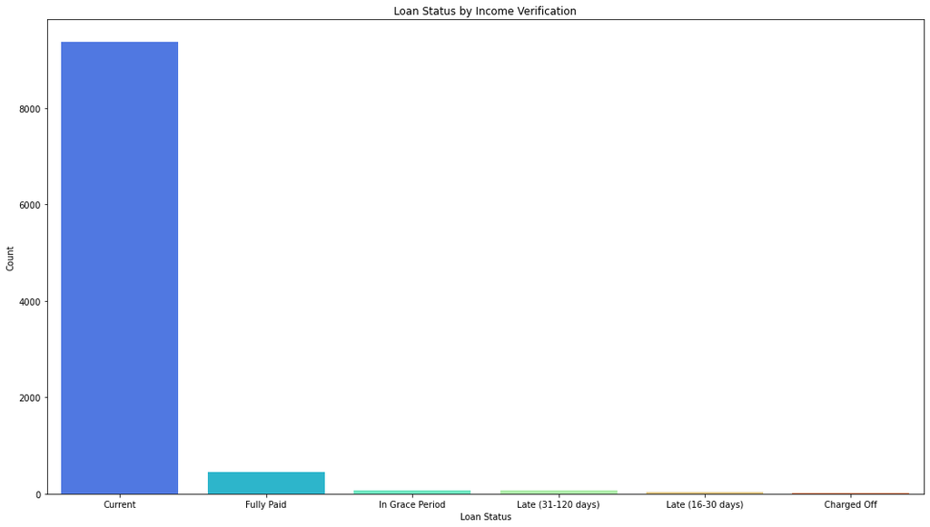

```python
from matplotlib import pyplot as plt
import seaborn as sns

a = data.groupby(['loan_status']).size().reset_index(name='count').sort_values(ascending=False, by='count')
plt.figure(figsize=(18,10))
g = sns.barplot(x='loan_status', y='count', data=a, palette='rainbow')
g.set_xlabel('Loan Status')
g.set_ylabel('Count')
plt.title("Loan Status by Income Verification")
```

Loan Records by their purpose.

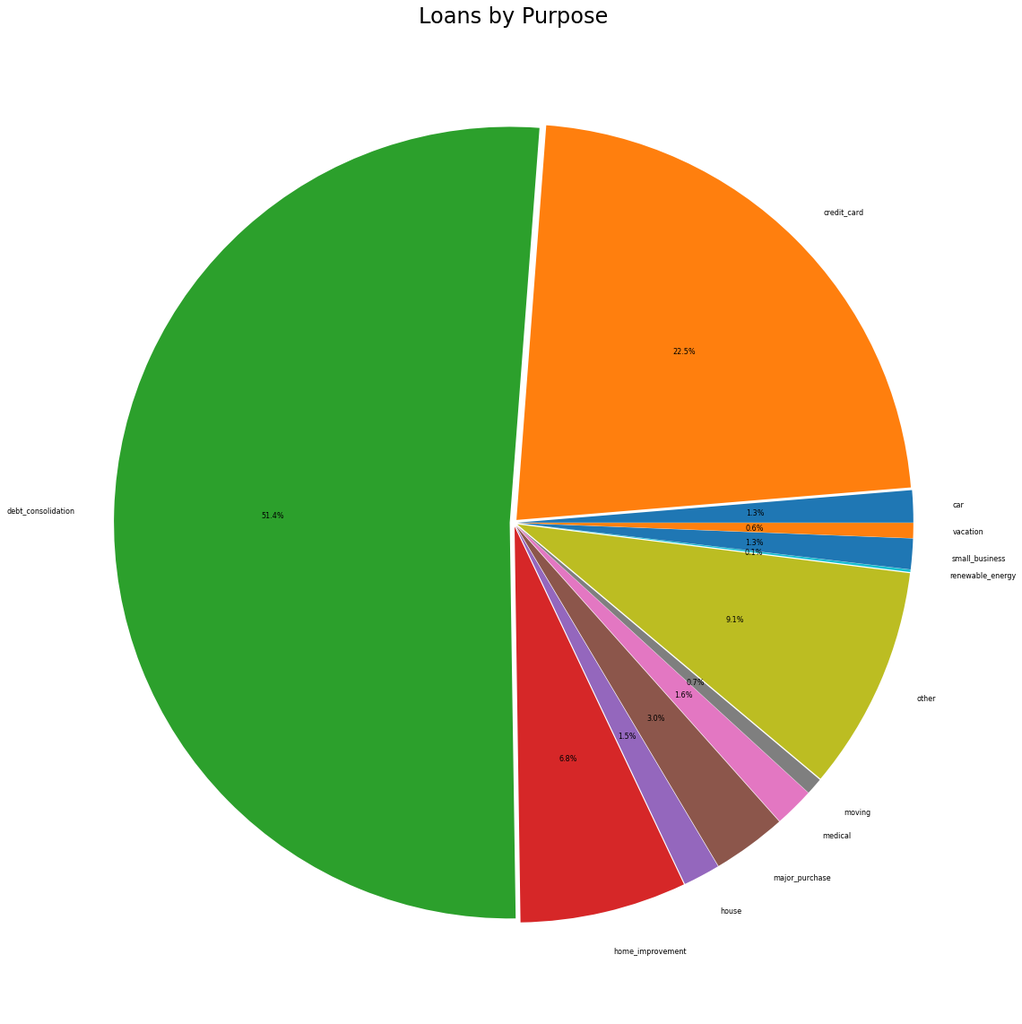

```python
a = data.groupby(['loan_purpose']).size().reset_index(name='count')
fig, ax = plt.subplots(figsize=(16, 16))
ax.pie(a['count'].to_numpy(), labels=a['loan_purpose'].to_numpy(),
       autopct='%.1f%%', textprops={'fontsize': 8}, explode=[0.01]*a['loan_purpose'].nunique())
ax.set_title('Loans by Purpose', fontdict={'fontsize': 24})
plt.tight_layout()
```

Loan Interest By Purpose

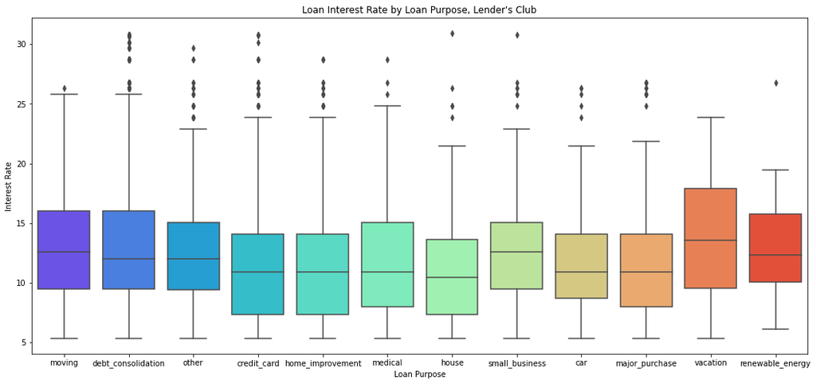

```python
plt.figure(figsize=(18,8))
sns.boxplot(x='loan_purpose',y='interest_rate',data=data, palette='rainbow')
plt.title("Loan Interest Rate by Loan Purpose, Lender's Club")
plt.xlabel('Loan Purpose')
plt.ylabel('Interest Rate')
```

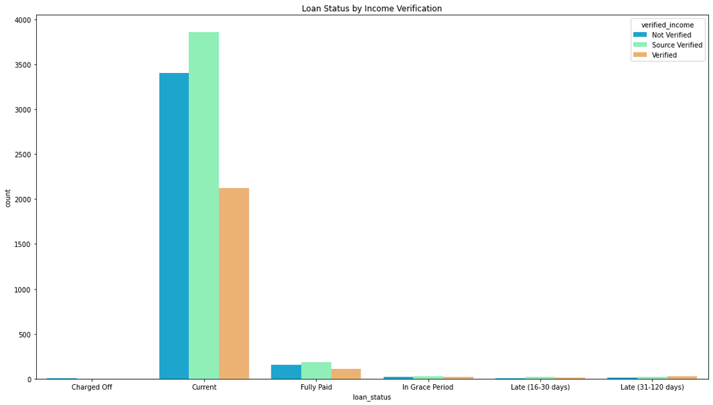

```python
a = data.groupby(['verified_income', 'loan_status']).size().reset_index(name='count')
plt.figure(figsize=(18,10))
sns.barplot(x='loan_status',y='count',data=a, palette='rainbow', hue='verified_income')
plt.title("Loan Status by Income Verification")
```

Average Interest Rate by State

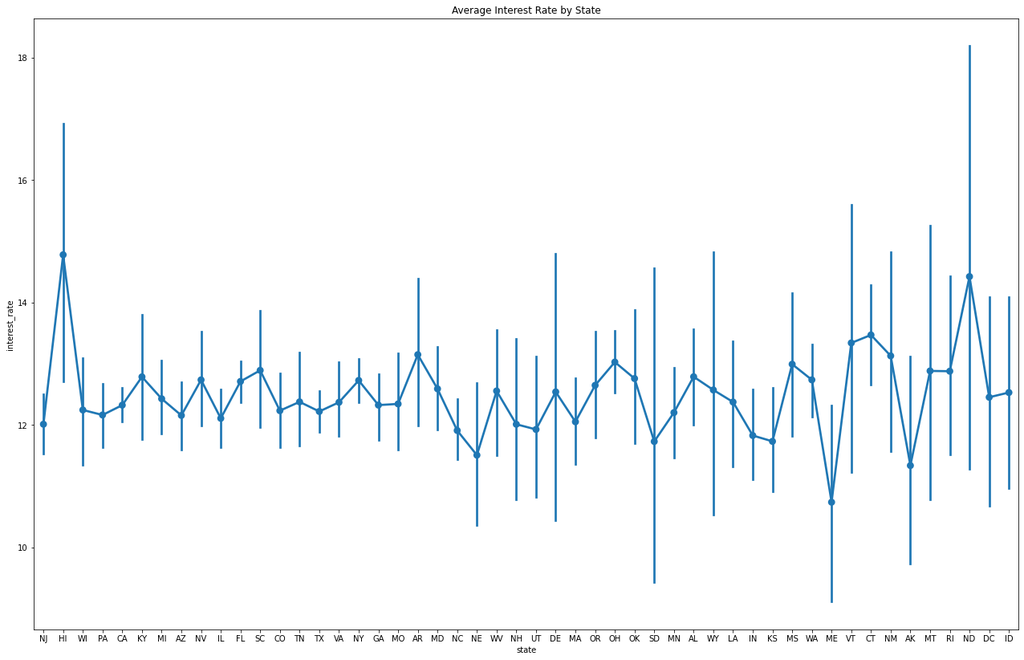

```python
plt.figure(figsize=(22,14))
sns.pointplot(x='state',y='interest_rate',data=data)
plt.title("Average Interest Rate by State")
```

# Modelling & Training

## Data Preprocessing

```python
from sklearn.preprocessing import LabelEncoder, MinMaxScaler
# Feature Engineering Dataset

# Removing rows/data based on null condition of certain columns
# remove rows with missing debt_to_income value (since the numbers are very less it shouldn't effect the accuracy much) - only 24 such rows found in exploration stage.
data = data[data['debt_to_income'].notna()]

# Merging Columns of data based information gained during exploratory analysis stage.

# Replacing null values in annual_income_joint with corresponding values from annual_income column;
data.annual_income_joint.fillna(data.annual_income, inplace=True)
# renaming merged column annual_income_joint as annual_income_merged
data.rename({'annual_income_joint': 'annual_income_merged'}, inplace=True)

# Removing meaningless to the motive features from dataframe
data.drop(columns=['emp_title', 'verification_income_joint', 'annual_income', 'debt_to_income_joint',
          'num_accounts_120d_past_due'], axis=1, inplace=True)  # remove unnecessary columns
# renaming merged column annual_income__merged to annual_income
data.rename({'annual_income_merged': 'annual_income'}, inplace=True)


# Label Encoding categorical values & removing the categorical columns from the dataset
labelEncoder = LabelEncoder()

data['state_cat'] = labelEncoder.fit_transform(data['state'])
data['homeownership_cat'] = labelEncoder.fit_transform(data['homeownership'])
data['verified_income_cat'] = labelEncoder.fit_transform(
    data['verified_income'])
data['loan_purpose_cat'] = labelEncoder.fit_transform(data['loan_purpose'])
data['application_type_cat'] = labelEncoder.fit_transform(
    data['application_type'])
data['grade_cat'] = labelEncoder.fit_transform(data['grade'])
data['sub_grade_cat'] = labelEncoder.fit_transform(data['sub_grade'])
data['issue_month_cat'] = labelEncoder.fit_transform(data['issue_month'])
data['loan_status_cat'] = labelEncoder.fit_transform(data['loan_status'])
data['initial_listing_status_cat'] = labelEncoder.fit_transform(
    data['initial_listing_status'])
data['disbursement_method'] = labelEncoder.fit_transform(
    data['disbursement_method'])


data.drop(columns=[
    'state',
    'homeownership',
    'verified_income',
    'loan_purpose',
    'application_type',
    'grade',
    'sub_grade',
    'issue_month',
    'loan_status',
    'initial_listing_status',
    'disbursement_method',
], inplace=True)



scaler = MinMaxScaler().fit(data.values)
transform = scaler.transform(data.values)

data[data.columns] = transform


# Replacing -1 in case it isn't available (replacement with constant method).
data['months_since_90d_late'].replace(
    np.nan, -1, inplace=True)
data['emp_length'].replace(
    np.nan, -1, inplace=True)
data['months_since_last_credit_inquiry'].replace(
    np.nan, -1, inplace=True)
data['months_since_last_delinq'].replace(
    np.nan, -1, inplace=True)
```

```python
# data_without_nulls.head()
print(data.info())
print(data.isnull().sum())
data.head()
```

```
<class 'pandas.core.frame.DataFrame'>
Int64Index: 9976 entries, 0 to 9999
Data columns (total 49 columns):
 #   Column                            Non-Null Count  Dtype
---  ------                            --------------  -----
 0   emp_length                        9976 non-null   float64
 1   debt_to_income                    9976 non-null   float64
 2   annual_income_joint               9976 non-null   float64
 3   delinq_2y                         9976 non-null   float64
 4   months_since_last_delinq          9976 non-null   float64
 5   earliest_credit_line              9976 non-null   float64
 6   inquiries_last_12m                9976 non-null   float64
 7   total_credit_lines                9976 non-null   float64
 8   open_credit_lines                 9976 non-null   float64
 9   total_credit_limit                9976 non-null   float64
 10  total_credit_utilized             9976 non-null   float64
 11  num_collections_last_12m          9976 non-null   float64
 12  num_historical_failed_to_pay      9976 non-null   float64
 13  months_since_90d_late             9976 non-null   float64
 14  current_accounts_delinq           9976 non-null   float64
 15  total_collection_amount_ever      9976 non-null   float64
 16  current_installment_accounts      9976 non-null   float64
 17  accounts_opened_24m               9976 non-null   float64
 18  months_since_last_credit_inquiry  9976 non-null   float64
 19  num_satisfactory_accounts         9976 non-null   float64
 20  num_accounts_30d_past_due         9976 non-null   float64
 21  num_active_debit_accounts         9976 non-null   float64
 22  total_debit_limit                 9976 non-null   float64
 23  num_total_cc_accounts             9976 non-null   float64
 24  num_open_cc_accounts              9976 non-null   float64
 25  num_cc_carrying_balance           9976 non-null   float64
 26  num_mort_accounts                 9976 non-null   float64
 27  account_never_delinq_percent      9976 non-null   float64
 28  tax_liens                         9976 non-null   float64
 29  public_record_bankrupt            9976 non-null   float64
 30  loan_amount                       9976 non-null   float64
 31  term                              9976 non-null   float64
 32  interest_rate                     9976 non-null   float64
 33  installment                       9976 non-null   float64
 34  balance                           9976 non-null   float64
```

[output cut: 52 more lines]

```
paid_total                          0
paid_principal                      0
paid_interest                       0
paid_late_fees                      0
state_cat                           0
homeownership_cat                   0
verified_income_cat                 0
loan_purpose_cat                    0
application_type_cat                0
grade_cat                           0
sub_grade_cat                       0
issue_month_cat                     0
loan_status_cat                     0
initial_listing_status_cat          0
dtype: int64
```

|  | emp_length | debt_to_income | annual_income_joint | delinq_2y | months_since_last_delinq | earliest_credit_line | inquiries_last_12m | total_credit_lines | open_credit_lines | total_credit_limit | ... | state_cat | homeownership_cat | verified_income_cat | loan_purpose_cat | application_type_cat | grade_cat | sub_grade_cat | issue_month_cat | loan_status_cat | initial_listing_status_cat |
| --- | --- | --- | --- | --- | --- | --- | --- | --- | --- | --- | --- | --- | --- | --- | --- | --- | --- | --- | --- | --- | --- |
| 0 | 0.3 | 0.038393 | 0.036938 | 0.0 | 0.316239 | 0.730769 | 0.206897 | 0.305882 | 0.196078 | 0.020908 | ... | 0.612245 | 0.0 | 1.0 | 0.636364 | 0.0 | 0.333333 | 0.387097 | 1.0 | 0.2 | 1.0 |
| 1 | 1.0 | 0.010744 | 0.015150 | 0.0 | -1.000000 | 0.634615 | 0.034483 | 0.329412 | 0.274510 | 0.008506 | ... | 0.224490 | 1.0 | 0.0 | 0.181818 | 0.0 | 0.333333 | 0.322581 | 0.0 | 0.2 | 1.0 |
| 2 | 0.3 | 0.045087 | 0.015150 | 0.0 | 0.230769 | 0.826923 | 0.137931 | 0.341176 | 0.196078 | 0.007145 | ... | 0.959184 | 1.0 | 0.5 | 0.727273 | 0.0 | 0.500000 | 0.483871 | 0.0 | 0.2 | 0.0 |
| 3 | 0.1 | 0.021659 | 0.010792 | 0.0 | -1.000000 | 0.846154 | 0.000000 | 0.023529 | 0.078431 | 0.007501 | ... | 0.755102 | 1.0 | 0.0 | 0.181818 | 0.0 | 0.000000 | 0.064516 | 0.5 | 0.2 | 1.0 |
| 4 | 1.0 | 0.123558 | 0.022558 | 0.0 | -1.000000 | 0.865385 | 0.241379 | 0.235294 | 0.313725 | 0.020626 | ... | 0.081633 | 1.0 | 1.0 | 0.090909 | 1.0 | 0.333333 | 0.387097 | 1.0 | 0.2 | 1.0 |

5 rows × 49 columns

## Feature Selection

```
total_debit_limit     -0.253867
term                   0.358121
interest_rate          1.000000
paid_interest          0.514658
verified_income_cat    0.245414
grade_cat              0.969352
sub_grade_cat          0.992922
Name: interest_rate, dtype: float64
```

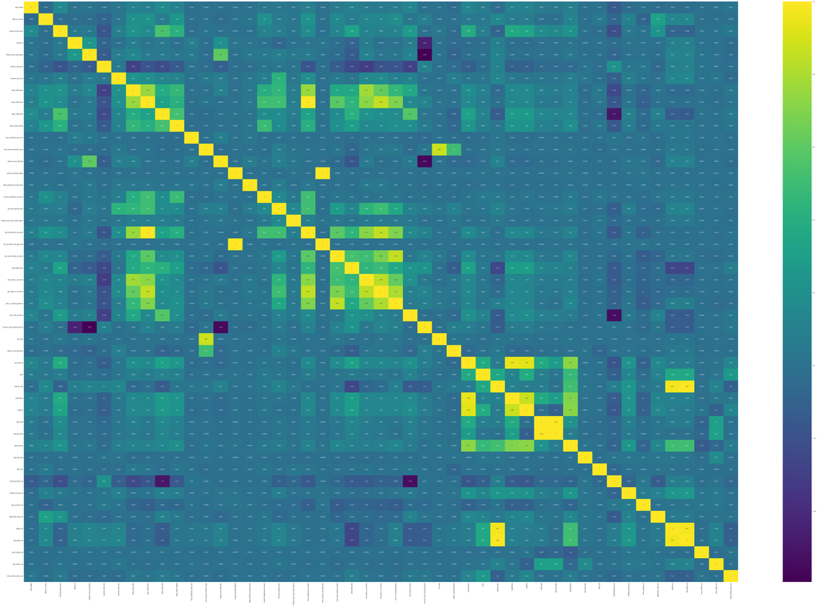

```python
plt.figure(figsize=(120, 80))
cor = data.corr()
cor_interest_rate = cor['interest_rate']
sns.heatmap(cor, annot=True, cmap='viridis')
print(cor_interest_rate[(cor_interest_rate >= 0.2) | (cor_interest_rate <= -0.2)])
```

## Feature Extraction

```python
feature_data = data[["total_debit_limit",
                     "term",
                     "interest_rate",
                     "paid_interest",
                     "verified_income_cat",
                     "grade_cat",
                     "sub_grade_cat", ]]
feature_data.isna().sum()
```

```
total_debit_limit      0
term                   0
interest_rate          0
paid_interest          0
verified_income_cat    0
grade_cat              0
sub_grade_cat          0
dtype: int64
```

## Separating Feature & Target Variable Data

```python
X, Y = pd.DataFrame(feature_data.loc[:, feature_data.columns != 'interest_rate']), pd.DataFrame(feature_data.loc[:, feature_data.columns == 'interest_rate'])
```

## Training

Splitting test and training data.

```python
from sklearn.model_selection import train_test_split
# splitting test and training data
X_train, X_test, y_train, y_test = train_test_split(X, Y, test_size=0.2, random_state=123)
```

### XGBoost Regression

```python
import xgboost as xgb
from sklearn.model_selection import RepeatedKFold
from sklearn.metrics import mean_squared_error as MSE

# fit model on training data
cv = RepeatedKFold(n_splits=10, n_repeats=3, random_state=1)
xg_reg = xgb.XGBRegressor(objective ='reg:linear', colsample_bytree = 0.3, learning_rate = 0.1,
                max_depth = 5, alpha = 10, n_estimators = 10)
xg_reg.fit(X_train,y_train)

y_pred = xg_reg.predict(X_test)
rmse = np.sqrt(MSE(y_test, y_pred))
print("RMSE: %f" % (rmse))
```

```
[12:51:25] WARNING: /Users/runner/miniforge3/conda-bld/xgboost-split_1645117899018/work/src/objective/regression_obj.cu:188: reg:linear is now deprecated in favor of reg:squarederror.
RMSE: 0.156491
```

#### XGBoost Model Prediction vs Actual Visualization

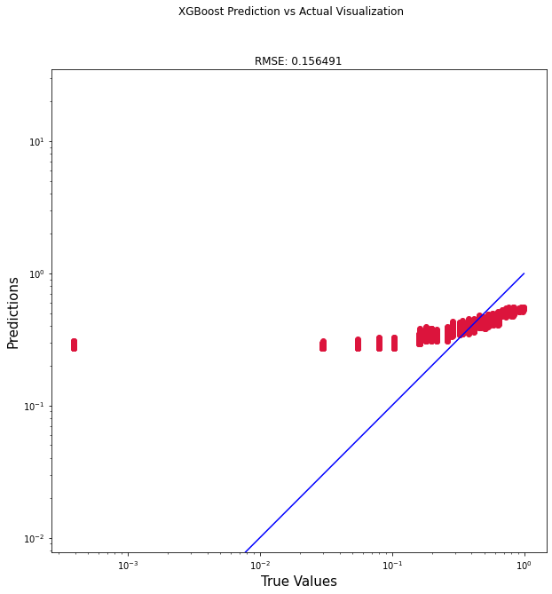

```python
y_test_viz = y_test.to_numpy()
plt.figure(figsize=(10,10))
plt.scatter(y_test_viz, y_pred, c='crimson')
plt.yscale('log')
plt.xscale('log')

p1 = max(max(y_pred), max(y_test_viz))
p2 = min(min(y_pred), min(y_test_viz))
plt.plot([p1, p2], [p1, p2], 'b-')
plt.xlabel('True Values', fontsize=15)
plt.ylabel('Predictions', fontsize=15)
plt.suptitle('XGBoost Prediction vs Actual Visualization')
plt.title("RMSE: %f" % (rmse))
plt.axis('equal')
plt.gca().set_aspect('equal', adjustable='datalim')
plt.show()
```

### Random Forest Regressor

```python
from sklearn.ensemble import RandomForestRegressor
import numpy as np
# create regressor object
regressor = RandomForestRegressor(n_estimators = 100, random_state = 0)

# fit the regressor with x and y data
regressor.fit(X_train, y_train)

y_pred = regressor.predict(X_test)
rmse = np.sqrt(MSE(y_test, y_pred))
print("RMSE: %f" % (rmse))
```

```
RMSE: 0.002960
```

#### RandomForestRegressor Prediction vs Actual Visualization

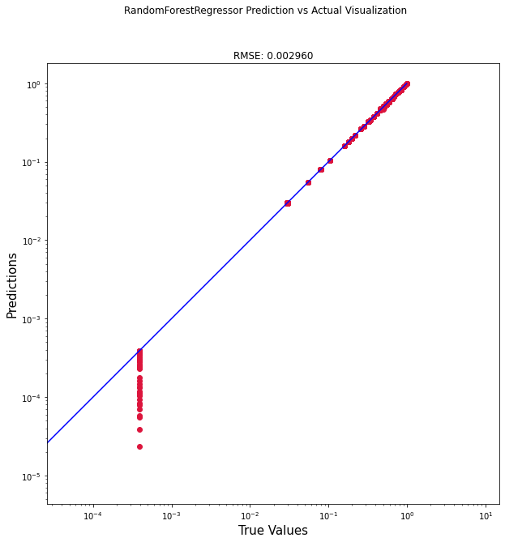

```python
plt.figure(figsize=(10,10))
plt.scatter(y_test_viz, y_pred, c='crimson')
plt.yscale('log')
plt.xscale('log')

p1 = max(max(y_pred), max(y_test_viz))
p2 = min(min(y_pred), min(y_test_viz))
plt.plot([p1, p2], [p1, p2], 'b-')
plt.xlabel('True Values', fontsize=15)
plt.ylabel('Predictions', fontsize=15)
plt.suptitle('RandomForestRegressor Prediction vs Actual Visualization')
plt.title("RMSE: %f" % (rmse))
plt.axis('equal')
plt.gca().set_aspect('equal', adjustable='datalim')
plt.show()
```

### MLPRegressor

```python
from sklearn.neural_network import MLPRegressor

regr = MLPRegressor(random_state=1, max_iter=500).fit(X_train, y_train)
y_pred = regr.predict(X_test)

print("MLPRegressor Score: %f" % (regr.score(X_test, y_test)))
```

```
MLPRegressor Score: 0.997348
```

#### MLPRegressor Prediction vs Actual Visualization

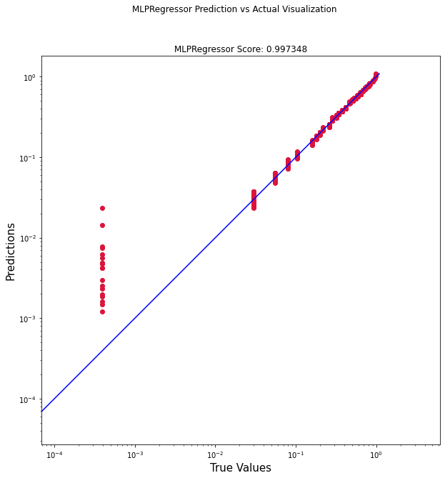

```python
plt.figure(figsize=(10,10))
plt.scatter(y_test_viz, y_pred, c='crimson')
plt.yscale('log')
plt.xscale('log')

p1 = max(max(y_pred), max(y_test_viz))
p2 = min(min(y_pred), min(y_test_viz))
plt.plot([p1, p2], [p1, p2], 'b-')
plt.xlabel('True Values', fontsize=15)
plt.ylabel('Predictions', fontsize=15)
plt.suptitle('MLPRegressor Prediction vs Actual Visualization')
plt.title("MLPRegressor Score: %f" % (regr.score(X_test, y_test)))
plt.axis('equal')
plt.gca().set_aspect('equal', adjustable='datalim')
plt.show()
```

# Summary

- tweak XGB linear regressor model parameters to tune it for better accuracy.
- go beyond these conventional methods to build more efficient model and inclined to this specific use case.

Assumptions:

- emp_title field is irrelevant to the interest rate as most of them are different and contains many null values.
- 24 rows in debt_to_income contains null, so removed those records as they represent less than 1% of the complete dataset.
- removed verification_income_joint field completely as it is a categorical value with enough nulls that if handled might corrupt the data.
- removed debt_to_income_joint field from consideration as debt_to_income is defined for the complete dataset i.e without any missing values, so considered just that.
- num_accounts_120d_past_due discarded from consideration for features for this prediction as it either contains null values or 0's which won't be of any use to this prediction.
- Replaced null values with -1 (as constant) for the missing values in months_since_90d_late, emp_length, months_since_last_credit_inquiry, months_since_last_delinq properties from the dataset.
- annual_income_joint supersedes annual_income. annual_income considered when annual_income_joint is null.